# Tutorial 3 Tasks Solution

## Task 1 - Modelling

### How do customer attributes and marketing efforts affect spending?

In order to optimally target customers the sales and marketing teams want to estimate how much a particular customer will spend, given a set of attributes.

#### 1 - Inspect and visualize the data to investigate which variables do you think would be helpful to explain output variable 'AmountSpent'

```python
import pandas as pd  # This helps us load, inspect, and manipulate data
import matplotlib.pyplot as plt  # This helps us plot and visualize the data
import seaborn as sns  # This helps us plot and visualize the data in a more fancy way
import statsmodels.formula.api as smf  # This is the package that contains most of the standard statistical models
```

```python
# Load in our data
marketing = pd.read_excel('DirectMarketing.xlsx')
```

```python
# Quickly inspect the data
marketing.head()
```

|  | Age | Gender | OwnHome | Married | Location | Salary | Children | History | Catalogs | AmountSpent |
| --- | --- | --- | --- | --- | --- | --- | --- | --- | --- | --- |
| 0 | Old | Female | Own | Single | Far | 47500 | 0 | High | 6 | 755 |
| 1 | Middle | Male | Rent | Single | Close | 63600 | 0 | High | 6 | 1318 |
| 2 | Young | Female | Rent | Single | Close | 13500 | 0 | Low | 18 | 296 |
| 3 | Middle | Male | Own | Married | Close | 85600 | 1 | High | 18 | 2436 |
| 4 | Middle | Female | Own | Single | Close | 68400 | 0 | High | 12 | 1304 |

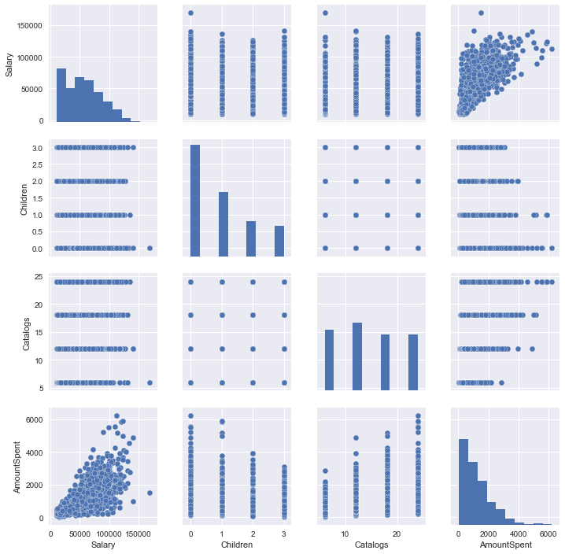

```python
# Plot a pairwise plot to quickly inspect the relationship between each pair of variables
# This only compares the numerical data
sns.pairplot(marketing)
plt.show()
```

From the pairwise plot, it seems like Salary is related to AmountSpent, but we're not really sure for the other two.

```python
# Let's investigate the relationship across the age groups
age_group = marketing.groupby('Age')
```

```python
# I am only interested in the AmountSpent attribute, and I want to summarize the AmountSpent for different age groups
age_group['AmountSpent'].describe()
```

| Age | count | mean | std | min | 25% | 50% | 75% | max |
| --- | --- | --- | --- | --- | --- | --- | --- | --- |
| Middle | 508.0 | 1501.690945 | 959.273125 | 157.0 | 815.75 | 1320.0 | 2008.5 | 5878.0 |
| Old | 205.0 | 1432.126829 | 1045.930027 | 65.0 | 638.00 | 1120.0 | 1985.0 | 6217.0 |
| Young | 287.0 | 558.623693 | 450.145949 | 38.0 | 248.50 | 422.0 | 699.0 | 3688.0 |

From the above, it seems like the average spending varies quite a lot between different age groups, BUT the error (standard deviation) is also high, so we cannot be sure that this difference is significant.

```python
# Let's investigate the relationship across the gender groups
gender_group = marketing.groupby('Gender')
```

```python
# I am only interested in the AmountSpent attribute, and I want to summarize the AmountSpent for different gender groups
gender_group['AmountSpent'].describe()
```

| Gender | count | mean | std | min | 25% | 50% | 75% | max |
| --- | --- | --- | --- | --- | --- | --- | --- | --- |
| Female | 506.0 | 1025.339921 | 910.529013 | 47.0 | 364.25 | 706.0 | 1442.0 | 5830.0 |
| Male | 494.0 | 1412.850202 | 972.769951 | 38.0 | 688.75 | 1216.0 | 1902.0 | 6217.0 |

From the above, it seems like the average spending varies quite a lot between different gender groups, BUT the error (standard deivation) is also high, so we cannot be sure that this difference is significant.

#### 2 - Build a linear regression model with dependant variable AmountSpent and independant variables Salary, Children, Gender and Catalogs.

```python
# Write down our formula that represents the model we are trying to model
# In plain English, the formula reads "AmountSpent is explained by Salary and Children and Gender and Catalogs"
formula = 'AmountSpent ~ Salary + Children + Gender + Catalogs'

# First, we will initlize the ordinary least squares function
# OLS: Ordinary Least Squares
# OLS is the algorithm to train our linear model, but it is not the linear model itself
model = smf.ols(formula, marketing)
```

```python
# Now, train the model by using the fit() method
results = model.fit()
```

```python
# Summarize my linear regression result
results.summary()
```

OLS Regression Results

| Dep. Variable: | AmountSpent | R-squared: | 0.659 |
| --- | --- | --- | --- |
| Model: | OLS | Adj. R-squared: | 0.657 |
| Method: | Least Squares | F-statistic: | 480.4 |
| Date: | Fri, 17 Aug 2018 | Prob (F-statistic): | 1.40e-230 |
| Time: | 17:46:33 | Log-Likelihood: | -7748.7 |
| No. Observations: | 1000 | AIC: | 1.551e+04 |
| Df Residuals: | 995 | BIC: | 1.553e+04 |
| Df Model: | 4 |  |  |
| Covariance Type: | nonrobust |  |  |

|  | coef | std err | t | P>\|t\| | [0.025 | 0.975] |
| --- | --- | --- | --- | --- | --- | --- |
| Intercept | -431.2400 | 54.680 | -7.887 | 0.000 | -538.541 | -323.939 |
| Gender[T.Male] | -41.7490 | 37.152 | -1.124 | 0.261 | -114.655 | 31.157 |
| Salary | 0.0206 | 0.001 | 33.534 | 0.000 | 0.019 | 0.022 |
| Children | -200.9904 | 17.207 | -11.681 | 0.000 | -234.756 | -167.224 |
| Catalogs | 47.7775 | 2.756 | 17.337 | 0.000 | 42.370 | 53.186 |

| Omnibus: | 257.549 | Durbin-Watson: | 1.983 |
| --- | --- | --- | --- |
| Prob(Omnibus): | 0.000 | Jarque-Bera (JB): | 995.294 |
| Skew: | 1.180 | Prob(JB): | 7.49e-217 |
| Kurtosis: | 7.279 | Cond. No. | 2.01e+05 |

#### 3 - Which variables are significant and which are not?

From the above, Salary, Children and Catalogs are significant, but Gender is probably not that significant so we could drop it from the model.

#### 4 - What is the $R^2$ value of the model? How could you potentially improve the model?

From the summary table or the rsquared attribute of the regression results object http://www.statsmodels.org/dev/generated/statsmodels.regression.linear_model.RegressionResults.html

Let's try with adding more variables. However, we must be aware not to overfit our model. We will discuss this further in the module on Model Selection.

```python
results.rsquared
```

```
0.65886832396594674
```

```python
formula_big = 'AmountSpent ~ Salary + Children + Gender + Catalogs + History + Age'

model_big = smf.ols(formula_big, marketing)

results_big = model_big.fit()

results_big.rsquared
```

```
0.72929213520421476
```

```python
# Create a dataframe containing the attribute of this particular customer
customers = pd.DataFrame({'Salary': [50000],
                         'Children': [0],
                         'Gender': ['Female'],
                         'Catalogs': [12]})
```

```python
# Use my ordinary least squares trained model to predict on this customer
results.predict(customers)
```

```
0    1171.331963
dtype: float64
```

#### 6 - Predict on multiple people at the same time (make up a few people that you might be interested in, does the result make sense to you?)

```python
# Create a dataframe containing the attribute of this particular customer
customers = pd.DataFrame({'Salary': [50000, 10000],
                         'Children': [0, 1],
                         'Catalogs': [12, 0],
                         'Gender': ['Female', 'Male']})
```

```python
# Use my ordinary least squares trained model to predict on these customer
results.predict(customers)
```

```
0    1171.331963
1    -468.131111
dtype: float64
```